[figure not shown]

# Modelos de Distribución de Especies (SDMs)

En este proyecto, se aborda la creación de un Modelo de Nicho de Especies mediante un proceso completo y estructurado. Desde la instalación y configuración de librerías hasta la recolección y preparación de datos climatológicos y geoespaciales. Se explora la implementación de Modelos de Distribución de Especies con un enfoque en el aprendizaje automático, detallando cada etapa y destacando los resultados obtenidos.

podemos dividir el proyecto en:

1. **Preparación de Datos y Configuración:**
   - Importación de librerías
   - Descarga de límites geográficos
   - Definición de la zona de estudio
2. **Adquisición y Preparación de Datos Climatológicos y Geoespaciales:**
   - Extracción de datos climatológicos
   - Revisión de variables disponibles
   - Recolección de variables de interés
   - Utilización de Worldclim y ETP Dataset
   - Uso de SRTM Digital Elevation Data Version 4
   - Obtención de datos de biodiversidad del GBIF
3. **Procesamiento de Datos Geoespaciales:**
   - Ajuste de los rasters
   - Captura de algunos datos de los rasters
4. **Implementación y Evaluación de Modelos de Distribución de Especies:**
   - Inicio del entrenamiento del modelo
   - Exportación del modelo
   - Conclusiones y resultados obtenidos

# Esto solo lo usamos en google colab

```python
# Instalamos librerias faltantes
#Installations
!apt update
!apt upgrade
!apt install gdal-bin python-gdal python3-gdal
!pip install rasterio
!apt install python3-rtree
!pip install descartes
#!pip install rioxarray
!pip install geopandas
#Instalamos folium
!pip install folium
!pip install pycrs
!pip install pyimpute
!!pip install pandasql
!pip install pygbif
!pip install fuzzywuzzy
```

[output not shown]

[output cut: 113 more lines]

[output not shown]

```python
from google.colab import drive
drive.mount('/content/drive')
```

## Importamos librerias

```python
import pandas as pd
import numpy as np
import matplotlib.pyplot as plt

import geopandas as gpd
import ee
import rasterio
import glob
import warnings
from shapely.geometry import Point
import fuzzywuzzy.fuzz as fuzz
import os
import zipfile
from os import makedirs, path as op

from rasterio.warp import calculate_default_transform, reproject, Resampling
from rasterio.merge import merge
import pycrs
from shapely.geometry import Polygon
import rasterio.plot
from pandasql import sqldf
import time
from pygbif import species, occurrences
from IPython.display import Image

import warnings

# Desactivar todas las advertencias
warnings.filterwarnings("ignore")
```

```python
 # Earth Engine Python API
ee.Authenticate()
ee.Initialize()
```

```
To authorize access needed by Earth Engine, open the following URL in a web browser and follow the instructions. If the web browser does not start automatically, please manually browse the URL below.

    https://code.earthengine.google.com/client-auth?scopes=https%3A//www.googleapis.com/auth/earthengine%20https%3A//www.googleapis.com/auth/devstorage.full_control&request_id=-O7Y0Yr6CC1L4WcPv-kU6yM3t9vhG5qA27ULc-yajc4&tc=IeaIUDmVMKIEHehMDRW-8NWvjNli8s-JGDy1RiC7qmk&cc=M_Kf5DVrN-FAwlL7bdIAQxWeFRPThE…

The authorization workflow will generate a code, which you should paste in the box below.
Enter verification code: 4/1Adeu5BUaPhF5ndu1fMYyJOOp-_zfrtFEjsUyP6OrilxrYVH4anvMOjfvqa0

Successfully saved authorization token.
```

## Descargamos lomites geograficos

Este código crea una carpeta "shp" y descarga un archivo de límites administrativos de Colombia en formato shapefile (SHP) en esa carpeta.

```python
# Creamos la carpeta de los shp
!mkdir ./shp
#Colombia
!wget https://biogeo.ucdavis.edu/data/diva/adm/COL_adm.zip -P ./shp
```

```
--2023-08-05 00:46:35--  https://biogeo.ucdavis.edu/data/diva/adm/COL_adm.zip
Resolving biogeo.ucdavis.edu (biogeo.ucdavis.edu)... 128.120.228.172
Connecting to biogeo.ucdavis.edu (biogeo.ucdavis.edu)|128.120.228.172|:443... connected.
HTTP request sent, awaiting response... 302 Found
Location: https://data.biogeo.ucdavis.edu/data/diva/adm/COL_adm.zip [following]
--2023-08-05 00:46:35--  https://data.biogeo.ucdavis.edu/data/diva/adm/COL_adm.zip
Resolving data.biogeo.ucdavis.edu (data.biogeo.ucdavis.edu)... 128.120.228.172
Connecting to data.biogeo.ucdavis.edu (data.biogeo.ucdavis.edu)|128.120.228.172|:443... connected.
HTTP request sent, awaiting response... 200 OK
Length: 2071901 (2.0M) [application/zip]
Saving to: ‘./shp/COL_adm.zip’

COL_adm.zip         100%[===================>]   1.98M  3.90MB/s    in 0.5s

2023-08-05 00:46:36 (3.90 MB/s) - ‘./shp/COL_adm.zip’ saved [2071901/2071901]
```

Descomprime todos los archivos ZIP en la carpeta "shp" en su ubicación actual. esto es para tener mejor organizados los datos geograficos

```python
# Descomprimir y reubicar
!unzip './shp/*.zip' -d './shp/'
```

```
Archive:  ./shp/COL_adm.zip
 extracting: ./shp/COL_adm0.cpg
  inflating: ./shp/COL_adm0.csv
  inflating: ./shp/COL_adm0.dbf
  inflating: ./shp/COL_adm0.prj
  inflating: ./shp/COL_adm0.shp
  inflating: ./shp/COL_adm0.shx
 extracting: ./shp/COL_adm1.cpg
  inflating: ./shp/COL_adm1.csv
  inflating: ./shp/COL_adm1.dbf
  inflating: ./shp/COL_adm1.prj
  inflating: ./shp/COL_adm1.shp
  inflating: ./shp/COL_adm1.shx
 extracting: ./shp/COL_adm2.cpg
  inflating: ./shp/COL_adm2.csv
  inflating: ./shp/COL_adm2.dbf
  inflating: ./shp/COL_adm2.prj
  inflating: ./shp/COL_adm2.shp
  inflating: ./shp/COL_adm2.shx
  inflating: ./shp/license.txt
```

## Definimos zona de estudio

Este código crea un polígono con coordenadas geográficas en latitud y longitud, formando una figura cerrada en un plano cartesiano bidimensional. Esto es debido a que existen islas que hacen parte del departamento del area de estudio y no nos interesa para este ejercicio. Por lo cual vamos a definir un poligono geografico para definir mejor el area.

```python
lat_point_list = [ 2.5,    5,   5, 2.5]
lon_point_list = [ -78,   -78,  -73.87033081,-73.87033081]
polygon_geom = Polygon(zip(lon_point_list, lat_point_list))
polygon_geom
```

Este código carga datos geoespaciales de Colombia, selecciona la región "Valle del Cauca", la recorta usando un polígono y genera un mapa que muestra esta área específica.

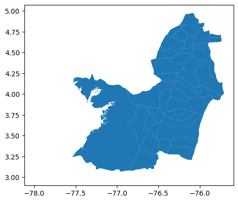

```python
# Cargar el archivo de datos geoespaciales de Colombia y cambiar su sistema de coordenadas
col = gpd.read_file('/content/shp/COL_adm2.shp').to_crs("EPSG:4326")

# Seleccionar la región "Valle del Cauca" del archivo cargado
zone = col[col["NAME_1"] == "Valle del Cauca"]

# Recortar la región seleccionada usando un polígono previamente definido
zone = zone.clip(polygon_geom)

# Generar un mapa para visualizar la región recortada
zone.plot()
```

Este código utiliza Matplotlib para crear un gráfico. Se establece el tamaño y se grafica una región geográfica con un estilo específico. Se crea una leyenda con un marcador cuadrado azul. Luego se personalizan el título, etiquetas de ejes y cuadrícula. Finalmente, se muestra el gráfico.

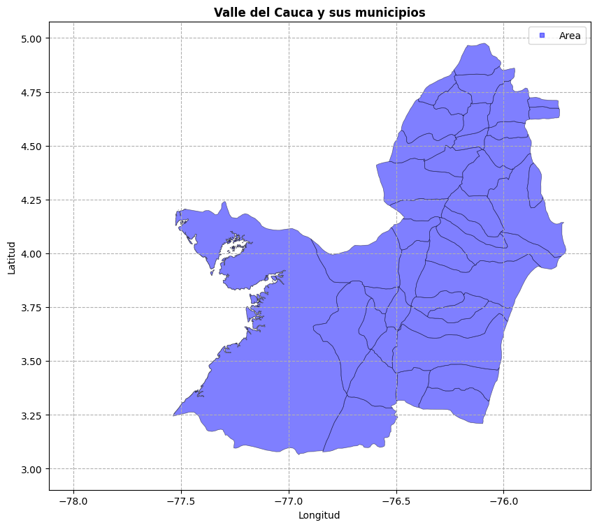

```python
import matplotlib.pyplot as plt
from matplotlib.lines import Line2D

# Configurar el tamaño de la figura
fig, ax = plt.subplots(figsize=(10, 10))

# Graficar los geodataframes con opciones de estilo personalizadas
buenav_plot = zone.plot(ax=ax, color='blue', edgecolor='black', linewidth=0.5, alpha=0.5)

# Crear objetos de leyenda personalizados
legend_elements = [
    Line2D([0], [0], marker='s', color='blue', label='Area', markersize=5, linestyle='', alpha=0.5)
]

# Mostrar la leyenda
ax.legend(handles=legend_elements)

# Personalizar el aspecto del gráfico
ax.set_title('Valle del Cauca y sus municipios', fontweight='bold')
ax.set_xlabel('Longitud')
ax.set_ylabel('Latitud')
ax.grid(linestyle="--")

# Mostrar el gráfico
plt.show()
```

## Extraemos los datos climatologicos

[figure not shown]

Este código utiliza Earth Engine para analizar datos de temperatura de la superficie terrestre MODIS. Filtra datos entre dos fechas, selecciona bandas apropiadas y escala. Define una ubicación urbana. Calcula y muestra el promedio de temperatura diurna en ese punto.

```python
import warnings

# Ignorar todas las advertencias
warnings.filterwarnings("ignore")

# Importar la colección de temperatura de superficie terrestre MODIS.
lst = ee.ImageCollection('MODIS/006/MOD11A1')

# Fecha inicial de interés (inclusive).
i_date = '2017-01-01'

# Fecha final de interés (exclusiva).
f_date = '2020-01-01'

# Selección de bandas y fechas apropiadas para la temperatura de superficie terrestre.
lst = lst.select('LST_Day_1km', 'QC_Day').filterDate(i_date, f_date)
scale = 1000  # escala en metros

# Definir la ubicación urbana de interés como un punto cerca del área de estudio.
u_lon = zone.geometry.centroid.x.values[0]  # -73.870331
u_lat = zone.geometry.centroid.y.values[0]  # 3.228429
u_poi = ee.Geometry.Point(u_lon, u_lat)

# Restaurar el comportamiento predeterminado de advertencias
warnings.filterwarnings("default")

# Calcular e imprimir el valor promedio de la colección de temperatura en el punto.
lst_urban_point = lst.mean().sample(u_poi, scale).first().get('LST_Day_1km').getInfo()
print('Temperatura promedio diurna en el punto urbano:', round(lst_urban_point*0.02 -273.15, 2), '°C')
```

```
Temperatura promedio diurna en el punto urbano: 25.13 °C
```

Este código convierte un polígono multiparte en una colección de características individuales de Earth Engine, cada una representando un componente del polígono original.

```python
# Convertir polígono multiparte en una colección de características individuales
zone_explode = zone.explode(index_parts=False)  # Descomponer polígono
geom = [i for i in zone_explode.geometry]
features = []

# Crear características para cada componente del polígono
for i in range(len(geom)):
    x, y = geom[i].exterior.coords.xy
    cords = np.dstack((x, y)).tolist()

    g = ee.Geometry.Polygon(cords)
    feature = ee.Feature(g)
    features.append(feature)
    print("Hecho")

# Crear una colección de características de Earth Engine
ee_object = ee.FeatureCollection(features)
```

[output not shown]

[output cut: 35 more lines]

[output not shown]

[output not shown]

## Revisar variables disponibles

Vamos a obtener las distintas variables climatologicas que tenemos disponibles a traves del dataset `WORLDCLIM/V1/BIO`

```python
# Cargar imagen de datos climáticos globales de WorldClim
worldclim_img = ee.Image("WORLDCLIM/V1/BIO")

# Ajustar por factor de escala para la temperatura promedio
worldclim_img_tavg = worldclim_img.select('bio01').multiply(0.1)
worldclim_img_tavg = worldclim_img_tavg.clip(ee_object)  # Recortar a la región de interés

# Ajustar por factor de escala para la precipitación
worldclim_img_prec = worldclim_img.select('bio12')
worldclim_img_prec = worldclim_img_prec.clip(ee_object)  # Recortar a la región de interés
```

Esta función en Python procesa imágenes de datos climáticos de WorldClim en Earth Engine. Calcula los valores mínimos y máximos de temperatura o precipitación para una región de interés y los muestra.

```python
def reduce_worldclim_collection(ee_object, worldclim_img, data_type):
    """
    Reduce the WorldClim image collection to calculate minimum and maximum values
    of temperature or precipitation for a specified region of interest.

    Parameters:
        ee_object (ee.Geometry): Earth Engine geometry representing the region of interest.
        worldclim_img (ee.Image): WorldClim image to process.
        data_type (str): Type of data to process. Use 'ppt' for precipitation or 'temp' for temperature.

    Returns:
        None
    """

    def get_min_max(f):
        min = f.reduceRegion(
            reducer=ee.Reducer.min(),
            geometry=ee_object.geometry(),
            scale=1000,
            maxPixels=1e9).getInfo()

        max = f.reduceRegion(
            reducer=ee.Reducer.max(),
            geometry=ee_object.geometry(),
            scale=1000,
            maxPixels=1e9).getInfo()

        return min, max

    if data_type == 'ppt':
        min_val, max_val = get_min_max(worldclim_img)
        print("Ppt (mm) min and max")
    elif data_type == 'temp':
        min_val, max_val = get_min_max(worldclim_img)
        print("Temp(°C) min and max")
    else:
        raise ValueError("Invalid data_type. Use 'ppt' or 'temp'.")

    display(min_val, max_val)
    print("-*-" * 50)

# Lista de pares de imágenes (ee_object, worldclim_img, data_type)
image_list = [
    (ee_object, worldclim_img_prec, 'ppt'),
    (ee_object, worldclim_img_tavg, 'temp')
]

# Aplicar la función a cada par de imágenes usando map y lambda
list(map(lambda img_pair: reduce_worldclim_collection(*img_pair), image_list))
```

```
Ppt (mm) min and max
```

```
{'bio12': 959}
```

```
{'bio12': 8897}
```

```
-*--*--*--*--*--*--*--*--*--*--*--*--*--*--*--*--*--*--*--*--*--*--*--*--*--*--*--*--*--*--*--*--*--*--*--*--*--*--*--*--*--*--*--*--*--*--*--*--*--*-
Temp(°C) min and max
```

```
{'bio01': 4.800000000000001}
```

```
{'bio01': 26.700000000000003}
```

```
[None, None]
```

# Recolectamos las variables de interes

## Worldclim y ETP Dataset

Este código crea un diccionario que mapea nombres de variables climáticas a sus descripciones y factores de conversión asociados. Cada clave es un código de variable (por ejemplo, 'bio01') y cada valor es una tupla con el nombre de la variable y su factor de conversión.

```python
# Diccionario con el numero de bandas el nombre de la variable y factor de conversion
rasters_dicts = {
    'bio01': ('annual_mean_temperature', 0.1),
    'bio02': ('mean_diurnal_range', 0.1),
    'bio03': ('isothermality', 1),
    'bio04': ('temperature_seasonality', 0.01),
    'bio05': ('max_temperature_of_warmest_month', 0.1),
    'bio06': ('min_temperature_of_coldest_month', 0.1),
    'bio07': ('temperature_annual_range', 0.1),
    'bio08': ('mean_temperature_of_wettest_quarter', 0.1),
    'bio09': ('mean_temperature_of_driest_quarter', 0.1),
    'bio10': ('mean_temperature_of_warmest_quarter', 0.1),
    'bio11': ('mean_temperature_of_coldest_quarter', 0.1),
    'bio12': ('annual_precipitation', 1),
    'bio13': ('precipitation_of_wettest_month', 1),
    'bio14': ('precipitation_of_driest_month', 1),
    'bio15': ('precipitation_seasonality', 1),
    'bio16': ('precipitation_of_wettest_quarter', 1),
    'bio17': ('precipitation_of_driest_quarter', 1),
    'bio18': ('precipitation_of_warmest_quarter', 1),
    'bio19': ('precipitation_of_coldest_quarter', 1)
}
```

Este código realiza las siguientes tareas para la zona "Valle del Cauca" utilizando datos de WorldClim y Google Earth Engine:

1. Crea geometrías poligonales a partir de los contornos de los polígonos en gdf.
2. Ajusta la escala de salida.
3. Itera a través de rasters_dicts y realiza lo siguiente:
- Si el factor de conversión es menor que 1:
  - Selecciona la banda de imagen del conjunto de datos de WorldClim, ajusta la escala y recorta según la geometría.
  - Configura una tarea de exportación de imagen de Earth Engine y la inicia.
- Si el factor de conversión no es menor que 1, realiza un proceso similar sin multiplicación.

Descarga los datos de evapotranspiración de et_monthly en la zona. 5. Reduce la colección de imágenes de WorldClim por medio y selecciona la banda 'b1'. 6. Configura y ejecuta una tarea de exportación de imagen para los datos de evapotranspiración.

```python
# Inicia el contador de tiempo
%%time

# Importa la librería time para pausar la ejecución en ciertos puntos
import time

# Itera a través de los datos de la zona 'valle_del_cauca' y sus geometrías
for j, gdf in zip(['valle_del_cauca'], [zone_explode]):

    # Convierte las geometrías de polígonos en una lista de geometrías individuales
    geom = [i for i in gdf.geometry]
    features = []

    # Para cada geometría individual
    for i in range(len(geom)):
        x, y = geom[i].exterior.coords.xy
        cords = np.dstack((x, y)).tolist()

        # Crea una geometría de polígono de Earth Engine
        g = ee.Geometry.Polygon(cords)
        feature = ee.Feature(g)
        features.append(feature)

    # Crea una colección de características de Earth Engine
    ee_object = ee.FeatureCollection(features)

    # Ajusta la escala de salida
    scale_factor = 90 / 1000  # Factor de escala para cambiar de 1000 a 90 metros

    # Itera a través del diccionario de rasters y sus detalles
    for k, v in rasters_dicts.items():
        print("-*" * 75)
        print(k)
        worldclim_img = ee.Image("WORLDCLIM/V1/BIO")

        # Si el factor de conversión es menor que 1, realiza multiplicación y ajuste de escala
        if v[1] < 1:
            worldclim_img = worldclim_img.select(k).multiply(v[1]).clip(ee_object).unmask(-9999)
        else:
            # Si no, solo realiza el ajuste de escala
            worldclim_img = worldclim_img.select(k).clip(ee_object).unmask(-9999)

        img = worldclim_img
        name = v[0]

        # Configura y ejecuta una tarea de exportación de imagen a Google Drive
        task_config = {
            'image': img,
            'description': f'{j}_{name}',
            'scale': 1000 * scale_factor,
            'region': ee_object.geometry(),
            'folder': 'worldclim',
            'fileFormat': 'GeoTIFF',
            'crs': 'EPSG:4326'
        }
        task = ee.batch.Export.image.toDrive(**task_config)
        task.start()
        time.sleep(15)
        print(f'{j}_{name} done')
        print(f'>/' * 50)

    # Descarga los datos de evapotranspiración de un conjunto de imágenes
    et_monthly = ee.ImageCollection("projects/sat-io/open-datasets/global_et0/global_et0_monthly")

    # Reduce la colección de imágenes de WorldClim calculando el promedio
    worldclim_img_etp = et_monthly.mean().select('b1').clip(ee_object).unmask(-9999)
    img = worldclim_img_etp
    name = "evapotranspiration"

    # Configura y ejecuta una tarea de exportación de imagen de evapotranspiración
    task_config = {
        'image': img,
        'description': f'{j}_{name}',
        'scale': 1000 * scale_factor,
        'region': ee_object.geometry(),
        'folder': 'worldclim',
        'fileFormat': 'GeoTIFF',
        'crs': 'EPSG:4326'
    }
    task = ee.batch.Export.image.toDrive(**task_config)
    task.start()
    time.sleep(12)
    print(f'{j}_{name} done')
    print(f'>/' * 50)
```

```
-*-*-*-*-*-*-*-*-*-*-*-*-*-*-*-*-*-*-*-*-*-*-*-*-*-*-*-*-*-*-*-*-*-*-*-*-*-*-*-*-*-*-*-*-*-*-*-*-*-*-*-*-*-*-*-*-*-*-*-*-*-*-*-*-*-*-*-*-*-*-*-*-*-*-*
bio01
valle_del_cauca_annual_mean_temperature done
>/>/>/>/>/>/>/>/>/>/>/>/>/>/>/>/>/>/>/>/>/>/>/>/>/>/>/>/>/>/>/>/>/>/>/>/>/>/>/>/>/>/>/>/>/>/>/>/>/>/
-*-*-*-*-*-*-*-*-*-*-*-*-*-*-*-*-*-*-*-*-*-*-*-*-*-*-*-*-*-*-*-*-*-*-*-*-*-*-*-*-*-*-*-*-*-*-*-*-*-*-*-*-*-*-*-*-*-*-*-*-*-*-*-*-*-*-*-*-*-*-*-*-*-*-*
bio02
valle_del_cauca_mean_diurnal_range done
>/>/>/>/>/>/>/>/>/>/>/>/>/>/>/>/>/>/>/>/>/>/>/>/>/>/>/>/>/>/>/>/>/>/>/>/>/>/>/>/>/>/>/>/>/>/>/>/>/>/
-*-*-*-*-*-*-*-*-*-*-*-*-*-*-*-*-*-*-*-*-*-*-*-*-*-*-*-*-*-*-*-*-*-*-*-*-*-*-*-*-*-*-*-*-*-*-*-*-*-*-*-*-*-*-*-*-*-*-*-*-*-*-*-*-*-*-*-*-*-*-*-*-*-*-*
bio03
valle_del_cauca_isothermality done
>/>/>/>/>/>/>/>/>/>/>/>/>/>/>/>/>/>/>/>/>/>/>/>/>/>/>/>/>/>/>/>/>/>/>/>/>/>/>/>/>/>/>/>/>/>/>/>/>/>/
-*-*-*-*-*-*-*-*-*-*-*-*-*-*-*-*-*-*-*-*-*-*-*-*-*-*-*-*-*-*-*-*-*-*-*-*-*-*-*-*-*-*-*-*-*-*-*-*-*-*-*-*-*-*-*-*-*-*-*-*-*-*-*-*-*-*-*-*-*-*-*-*-*-*-*
bio04
valle_del_cauca_temperature_seasonality done
>/>/>/>/>/>/>/>/>/>/>/>/>/>/>/>/>/>/>/>/>/>/>/>/>/>/>/>/>/>/>/>/>/>/>/>/>/>/>/>/>/>/>/>/>/>/>/>/>/>/
-*-*-*-*-*-*-*-*-*-*-*-*-*-*-*-*-*-*-*-*-*-*-*-*-*-*-*-*-*-*-*-*-*-*-*-*-*-*-*-*-*-*-*-*-*-*-*-*-*-*-*-*-*-*-*-*-*-*-*-*-*-*-*-*-*-*-*-*-*-*-*-*-*-*-*
bio05
valle_del_cauca_max_temperature_of_warmest_month done
>/>/>/>/>/>/>/>/>/>/>/>/>/>/>/>/>/>/>/>/>/>/>/>/>/>/>/>/>/>/>/>/>/>/>/>/>/>/>/>/>/>/>/>/>/>/>/>/>/>/
-*-*-*-*-*-*-*-*-*-*-*-*-*-*-*-*-*-*-*-*-*-*-*-*-*-*-*-*-*-*-*-*-*-*-*-*-*-*-*-*-*-*-*-*-*-*-*-*-*-*-*-*-*-*-*-*-*-*-*-*-*-*-*-*-*-*-*-*-*-*-*-*-*-*-*
bio06
valle_del_cauca_min_temperature_of_coldest_month done
>/>/>/>/>/>/>/>/>/>/>/>/>/>/>/>/>/>/>/>/>/>/>/>/>/>/>/>/>/>/>/>/>/>/>/>/>/>/>/>/>/>/>/>/>/>/>/>/>/>/
-*-*-*-*-*-*-*-*-*-*-*-*-*-*-*-*-*-*-*-*-*-*-*-*-*-*-*-*-*-*-*-*-*-*-*-*-*-*-*-*-*-*-*-*-*-*-*-*-*-*-*-*-*-*-*-*-*-*-*-*-*-*-*-*-*-*-*-*-*-*-*-*-*-*-*
bio07
valle_del_cauca_temperature_annual_range done
>/>/>/>/>/>/>/>/>/>/>/>/>/>/>/>/>/>/>/>/>/>/>/>/>/>/>/>/>/>/>/>/>/>/>/>/>/>/>/>/>/>/>/>/>/>/>/>/>/>/
-*-*-*-*-*-*-*-*-*-*-*-*-*-*-*-*-*-*-*-*-*-*-*-*-*-*-*-*-*-*-*-*-*-*-*-*-*-*-*-*-*-*-*-*-*-*-*-*-*-*-*-*-*-*-*-*-*-*-*-*-*-*-*-*-*-*-*-*-*-*-*-*-*-*-*
bio08
valle_del_cauca_mean_temperature_of_wettest_quarter done
>/>/>/>/>/>/>/>/>/>/>/>/>/>/>/>/>/>/>/>/>/>/>/>/>/>/>/>/>/>/>/>/>/>/>/>/>/>/>/>/>/>/>/>/>/>/>/>/>/>/
-*-*-*-*-*-*-*-*-*-*-*-*-*-*-*-*-*-*-*-*-*-*-*-*-*-*-*-*-*-*-*-*-*-*-*-*-*-*-*-*-*-*-*-*-*-*-*-*-*-*-*-*-*-*-*-*-*-*-*-*-*-*-*-*-*-*-*-*-*-*-*-*-*-*-*
bio09
valle_del_cauca_mean_temperature_of_driest_quarter done
>/>/>/>/>/>/>/>/>/>/>/>/>/>/>/>/>/>/>/>/>/>/>/>/>/>/>/>/>/>/>/>/>/>/>/>/>/>/>/>/>/>/>/>/>/>/>/>/>/>/
-*-*-*-*-*-*-*-*-*-*-*-*-*-*-*-*-*-*-*-*-*-*-*-*-*-*-*-*-*-*-*-*-*-*-*-*-*-*-*-*-*-*-*-*-*-*-*-*-*-*-*-*-*-*-*-*-*-*-*-*-*-*-*-*-*-*-*-*-*-*-*-*-*-*-*
bio10
valle_del_cauca_mean_temperature_of_warmest_quarter done
>/>/>/>/>/>/>/>/>/>/>/>/>/>/>/>/>/>/>/>/>/>/>/>/>/>/>/>/>/>/>/>/>/>/>/>/>/>/>/>/>/>/>/>/>/>/>/>/>/>/
```

[output cut: 25 more lines]

```
bio17
valle_del_cauca_precipitation_of_driest_quarter done
>/>/>/>/>/>/>/>/>/>/>/>/>/>/>/>/>/>/>/>/>/>/>/>/>/>/>/>/>/>/>/>/>/>/>/>/>/>/>/>/>/>/>/>/>/>/>/>/>/>/
-*-*-*-*-*-*-*-*-*-*-*-*-*-*-*-*-*-*-*-*-*-*-*-*-*-*-*-*-*-*-*-*-*-*-*-*-*-*-*-*-*-*-*-*-*-*-*-*-*-*-*-*-*-*-*-*-*-*-*-*-*-*-*-*-*-*-*-*-*-*-*-*-*-*-*
bio18
valle_del_cauca_precipitation_of_warmest_quarter done
>/>/>/>/>/>/>/>/>/>/>/>/>/>/>/>/>/>/>/>/>/>/>/>/>/>/>/>/>/>/>/>/>/>/>/>/>/>/>/>/>/>/>/>/>/>/>/>/>/>/
-*-*-*-*-*-*-*-*-*-*-*-*-*-*-*-*-*-*-*-*-*-*-*-*-*-*-*-*-*-*-*-*-*-*-*-*-*-*-*-*-*-*-*-*-*-*-*-*-*-*-*-*-*-*-*-*-*-*-*-*-*-*-*-*-*-*-*-*-*-*-*-*-*-*-*
bio19
valle_del_cauca_precipitation_of_coldest_quarter done
>/>/>/>/>/>/>/>/>/>/>/>/>/>/>/>/>/>/>/>/>/>/>/>/>/>/>/>/>/>/>/>/>/>/>/>/>/>/>/>/>/>/>/>/>/>/>/>/>/>/
valle_del_cauca_evapotranspiration done
>/>/>/>/>/>/>/>/>/>/>/>/>/>/>/>/>/>/>/>/>/>/>/>/>/>/>/>/>/>/>/>/>/>/>/>/>/>/>/>/>/>/>/>/>/>/>/>/>/>/
CPU times: user 34.2 s, sys: 419 ms, total: 34.6 s
Wall time: 6min 3s
```

## SRTM Digital Elevation Data Version 4

El código descarga y exporta imágenes de elevación desde el conjunto de datos SRTM90 de Earth Engine para la región del Valle del Cauca.

```python
# Inicia el contador de tiempo
%%time
# Importa la librería time para pausar la ejecución en ciertos puntos
import time

# Carga el conjunto de datos de elevación SRTM90
dataset = ee.Image("CGIAR/SRTM90_V4")

# Itera a través de los datos de la zona 'valle_del_cauca' y sus geometrías
for j, gdf in zip(['valle_del_cauca'], [zone_explode]):

    # Convierte las geometrías de polígonos en una lista de geometrías individuales
    geom = [i for i in gdf.geometry]
    features = []

    # Para cada geometría individual
    for i in range(len(geom)):
        x, y = geom[i].exterior.coords.xy
        cords = np.dstack((x, y)).tolist()

        # Crea una geometría de polígono de Earth Engine
        g = ee.Geometry.Polygon(cords)
        feature = ee.Feature(g)
        features.append(feature)

    # Crea una colección de características de Earth Engine
    ee_object = ee.FeatureCollection(features)

    # Selecciona la banda de elevación y ajusta la escala
    elevation = dataset.select('elevation').clip(ee_object).unmask(-9999)

    # Lista de imágenes y nombres
    imgs = [elevation]
    names = ['elevation']

    try:
        # Itera a través de las imágenes y nombres
        for img, name in zip(imgs, names):
            # Configura y ejecuta una tarea de exportación de imagen a Google Drive
            task_config = {
                'image': img,
                'description': f'{j}_{name}',
                'scale': 90,  # Ajusta la escala
                'region': ee_object.geometry(),
                'folder': 'stmr_colombia',
                'fileFormat': 'GeoTIFF',
                'crs': 'EPSG:4326'
            }
            task = ee.batch.Export.image.toDrive(**task_config)
            task.start()
            print('--' * 75)
            print(f'{j} done')
            print(f'{j}_{name}')
            print('--' * 75)
    except:
        pass
```

```
------------------------------------------------------------------------------------------------------------------------------------------------------
valle_del_cauca done
valle_del_cauca_elevation
------------------------------------------------------------------------------------------------------------------------------------------------------
CPU times: user 1.53 s, sys: 15.2 ms, total: 1.54 s
Wall time: 3 s
```

## Datos de biodiversidad desde el GBIF

# GBIF (Global Biodiversity Information Facility)

El GBIF es una plataforma que recopila y proporciona acceso a datos de biodiversidad de todo el mundo. Esto es importante para la sociedad por varias razones:

- **Conservación y Gestión de la Biodiversidad:** Permite monitorear y entender la biodiversidad global, lo que es crucial para la conservación y gestión de especies y ecosistemas.
- **Investigación Científica:** Los datos del GBIF son fundamentales para la investigación en biología, ecología, evolución y muchas otras disciplinas.
- **Toma de Decisiones Basada en Datos:** Los datos del GBIF influyen en decisiones relacionadas con la biodiversidad y el medio ambiente.
- **Educación y Conciencia Pública:** Los datos del GBIF ayudan a educar al público sobre la biodiversidad y su importancia.

[figure not shown]

Este código define una función llamada minimum_bounding_rectangle que encuentra el rectángulo de menor tamaño que contiene un conjunto de puntos en un plano 2D. La función calcula el casco convexo de los puntos, determina las orientaciones de los bordes y rota el casco convexo en diferentes ángulos para encontrar el rectángulo óptimo que abarca los puntos. Devuelve las coordenadas de las esquinas del rectángulo delimitador.

```python
import numpy as np
from scipy.spatial import ConvexHull

def minimum_bounding_rectangle(points):
    """
    Encuentra el rectángulo de menor tamaño que contiene un conjunto de puntos.
    Devuelve un conjunto de puntos que representan las esquinas del rectángulo delimitador.

    :param points: una matriz nx2 de coordenadas
    :rval: una matriz nx2 de coordenadas
    """
    from scipy.ndimage.interpolation import rotate
    pi2 = np.pi/2.

    # Obtener el casco convexo para los puntos
    hull_points = points[ConvexHull(points).vertices]

    # Calcular los ángulos de los bordes
    edges = np.zeros((len(hull_points)-1, 2))
    edges = hull_points[1:] - hull_points[:-1]

    angles = np.zeros((len(edges)))
    angles = np.arctan2(edges[:, 1], edges[:, 0])

    angles = np.abs(np.mod(angles, pi2))
    angles = np.unique(angles)

    # Encontrar las matrices de rotación
    rotations = np.vstack([
        np.cos(angles),
        np.cos(angles-pi2),
        np.cos(angles+pi2),
        np.cos(angles)]).T
    rotations = rotations.reshape((-1, 2, 2))

    # Aplicar las rotaciones al casco convexo
    rot_points = np.dot(rotations, hull_points.T)

    # Encontrar los puntos límites del rectángulo
    min_x = np.nanmin(rot_points[:, 0], axis=1)
    max_x = np.nanmax(rot_points[:, 0], axis=1)
    min_y = np.nanmin(rot_points[:, 1], axis=1)
    max_y = np.nanmax(rot_points[:, 1], axis=1)

    # Encontrar el rectángulo con el mejor área
    areas = (max_x - min_x) * (max_y - min_y)
    best_idx = np.argmin(areas)

    # Obtener el rectángulo óptimo
    x1 = max_x[best_idx]
    x2 = min_x[best_idx]
    y1 = max_y[best_idx]
    y2 = min_y[best_idx]
    r = rotations[best_idx]

    rval = np.zeros((4, 2))
    rval[0] = np.dot([x1, y2], r)
    rval[1] = np.dot([x2, y2], r)
    rval[2] = np.dot([x2, y1], r)
    rval[3] = np.dot([x1, y1], r)

    return rval
```

La función `select_keys` selecciona claves específicas de un diccionario y devuelve un nuevo diccionario con esas claves. La función `calculate_similarity` calcula el porcentaje de similitud entre dos nombres utilizando el algoritmo `token_set_ratio` de la biblioteca `fuzzywuzzy`.

```python
def select_keys(dictionary, keys):
    """
    Selecciona las claves especificadas de un diccionario y devuelve un nuevo diccionario con esas claves.

    :param dictionary: el diccionario original
    :param keys: una lista de claves a seleccionar
    :return: un nuevo diccionario con las claves seleccionadas
    """
    selected_dict = dict(filter(lambda item: item[0] in keys, dictionary.items()))
    return selected_dict

def calculate_similarity(name1, name2):
    """
    Calculate the similarity percentage between two names.

    :param name1: the first name
    :param name2: the second name
    :return: the similarity percentage between the two names
    """
    # Get the first two names and concatenate them
    trimmed_name1 = "".join(name1.split()[:2])
    trimmed_name2 = "".join(name2.split()[:2])

    # Calculate the similarity using the token_set_ratio algorithm from fuzzywuzzy
    similarity = fuzz.token_set_ratio(trimmed_name1.lower(), trimmed_name2.lower())
    return similarity
```

Generamos una funcion para mostrar colores aleatoreos.

```python
import random

def generar_colores_aleatorios(num_colores):
    """
    Genera una lista de colores aleatorios sin repetición.

    :param num_colores: el número de colores a generar
    :return: una lista de colores aleatorios
    """
    colores_disponibles = ['red', 'blue', 'green', 'yellow', 'orange', 'purple', 'pink', 'brown']
    colores_aleatorios = random.sample(colores_disponibles, min(num_colores, len(colores_disponibles)))
    colores_aleatorios += ['white'] * max(0, num_colores - len(colores_disponibles))
    return colores_aleatorios
```

Vamos a llamar unas funciones auxiliares para realizar unas operaciones espaciales en el momento de comunicarnos con el API del GBIF

```python
from shapely import wkt
from shapely.geometry import MultiPolygon, Polygon
from shapely.ops import unary_union
```

La clase `SpeciesBoundingBox` representa un área geográfica con un conjunto de especies, y permite realizar varias operaciones en ella.El método `get_minimum_bounding_rectangle` calcula el rectángulo mínimo que contiene el polígono de interés, mientras que `find_species_in_quadrant` busca y recopila registros de especies que existen en un cuadrante específico dentro de ese rectángulo mínimo. La búsqueda de especies se realiza utilizando las coordenadas y nombres científicos de las especies en una zona geográfica específica. El resultado es un GeoDataFrame con los registros de especies encontrados en el cuadrante.

```python
class SpeciesBoundingBox:
    def __init__(self, polygon, species=[]):
        """
        Inicializa la clase MinimumBoundingRectangle.

        :param polygon: un polígono representado por una lista de puntos
        :param species: una lista de especies
        """
        self.polygon = polygon
        self.species = list(species)

    def get_minimum_bounding_rectangle(self):
        """
        Calcula el rectángulo mínimo para el polígono.

        :return: una lista de puntos que representan las esquinas del rectángulo mínimo
        """
        # Divide el objeto bna2 en polígonos que conforman el multipoligono original
        polygons = self.polygon.explode(index_parts=False)

        a = 0.25  # Asignación del valor 0.25 a la variable 'a'
        delta = 0.49  # Asignación del valor 0.49 a la variable 'delta'

        P = polygons.geometry.boundary  # Obtención de los límites de la geometría en la columna 'geometry' de 'bna2' y asignación a la variable 'P'

        eps = 0.01  # Asignación del valor 0.01 a la variable 'eps'
        # Creación de un objeto geométrico 'omega' mediante la unión de los polígonos generados a partir de los componentes de 'P'
        omega = unary_union([
            Polygon(component.coords).buffer(eps).buffer(-eps) for component in P
        ])
        # Convierte el objeto geométrico 'omega' en una cadena en formato WKT y la asigna a la variable 'wkt_string'
        wkt_string = wkt.dumps(omega)
        # Almacenamos los puntos en una lista
        points = [list(map(float, i.replace('(','').replace(')','').split(' ')[1:])) for i in wkt_string.split('POLYGON ')[1].split(',')[1:-1]]
        # Convertir points en un array de NumPy
        points_array = np.array(points)
        # Calculamos el cuadrante
        minimum_bounding_rect = minimum_bounding_rectangle(points_array)
        # Crear un objeto de geometría a partir de los puntos del rectángulo mínimo
        geometry = Polygon([[x, y] for x, y in minimum_bounding_rect.tolist()])

        # Crear un GeoDataFrame con la geometría del rectángulo y asignarle un sistema de referencia de coordenadas (crs)
        sector = gpd.GeoDataFrame(data=['data'], geometry=[geometry], crs=polygons.crs)
        return sector

    def find_species_in_quadrant(self):
        """
        Busca las especies que existen en un cuadrante específico del rectángulo mínimo.

        :param quadrant: el cuadrante en el que se desea buscar las especies
        :return: una lista de especies encontradas en el cuadrante
        """
        # Lógica para buscar las especies en el cuadrante...
        species_in_quadrant = []  # Lista de especies encontradas en el cuadrante
        quadrant=self.get_minimum_bounding_rectangle()
        zone = quadrant.geometry.to_wkt()
        selected_keys = ['acceptedTaxonKey', 'acceptedScientificName', 'family', 'genus', 'decimalLongitude', 'decimalLatitude', 'elevation',
                         'continent', 'stateProvince', 'eventDate', 'geodeticDatum', 'country', 'county', 'locality','hostingOrganizationKey']
        for i in self.species:
            data = occurrences.search(q=i, limit=1000, geometry=zone)
            for j in data['results']:
                if calculate_similarity(j.get('acceptedScientificName', ''),i) == 100:
                    result_dict = select_keys(j, selected_keys)
                    species_in_quadrant.append(result_dict)
        try:
            dfs = [pd.DataFrame([i]) for i in species_in_quadrant]
            if len(dfs) == 0:
                raise Exception("El área de búsqueda no posee ningún registro de las especies solicitadas. Por favor, intenta con otras especies u otra área de interés.")
            data = pd.concat(dfs, axis=0)

            # Vamos a hacer un GeoDataFrame con los puntos recolectados
            geometry = [Point(x,y) for x,y in data[['decimalLongitude', 'decimalLatitude']].values]
            # Almacenamos los datos en una nueva variable
            geo_points = gpd.GeoDataFrame(data, geometry=geometry, crs=quadrant.crs)
            geo_points = geo_points[selected_keys+["geometry"]]
            return geo_points
        except Exception as e:
            print(str(e))
```

Este código selecciona un área de interés, elige ciertas especies, crea una instancia de una clase para manejar esa área y esas especies, calcula un cuadrante mínimo que engloba el área, y busca las especies dentro del cuadrante. Mide el tiempo de ejecución.

```python
%%time
# Elegimos el area de interes
area = zone_explode.dissolve(by="ID_0")
# Elegimos las especies
list_sp = ["Carapa guianensis","Anacardium excelsum"]
# Insertamos los datos de entrada en nuestra clase previamente formada
test_obj = SpeciesBoundingBox(area,list_sp)
# Activamos el metodo para generar el cuadrante
recta_minum = test_obj.get_minimum_bounding_rectangle()
# Activamos el metodo para buscar las especies del cuadrante
sps = test_obj.find_species_in_quadrant()
```

```
CPU times: user 1min 28s, sys: 615 ms, total: 1min 28s
Wall time: 1min 34s
```

Este código muestra los primeros 5 registros de datos, las especies únicas presentes y un resumen del conjunto de datos, incluyendo información sobre columnas y tipos de datos.

```python
# Mostramos los primeros 5 registros
display(sps.head())
#Mostramos las especies
display(sps.acceptedScientificName.unique())
# Mostramos un resumen del conjunto de datos
sps.info()
```

|  | acceptedTaxonKey | acceptedScientificName | family | genus | decimalLongitude | decimalLatitude | elevation | continent | stateProvince | eventDate | geodeticDatum | country | county | locality | hostingOrganizationKey | geometry |
| --- | --- | --- | --- | --- | --- | --- | --- | --- | --- | --- | --- | --- | --- | --- | --- | --- |
| 0 | 3190513 | Carapa guianensis Aubl. | Meliaceae | Carapa | -76.994930 | 3.359870 | 186.0 | SOUTH_AMERICA | Valle del Cauca | 2017-01-01T00:00:00 | WGS84 | Colombia | Buenaventura | San Isidro | c4f66525-4d36-4c18-82ac-98e088f54db4 | POINT (-76.99493 3.35987) |
| 0 | 3190513 | Carapa guianensis Aubl. | Meliaceae | Carapa | -76.994930 | 3.359870 | 186.0 | SOUTH_AMERICA | Valle del Cauca | 2017-01-01T00:00:00 | WGS84 | Colombia | Buenaventura | San Isidro | c4f66525-4d36-4c18-82ac-98e088f54db4 | POINT (-76.99493 3.35987) |
| 0 | 3190513 | Carapa guianensis Aubl. | Meliaceae | Carapa | -77.129940 | 3.089840 | 202.0 | SOUTH_AMERICA | Cauca | 2017-01-01T00:00:00 | WGS84 | Colombia | López de Micay | La Estrella | c4f66525-4d36-4c18-82ac-98e088f54db4 | POINT (-77.12994 3.08984) |
| 0 | 3190513 | Carapa guianensis Aubl. | Meliaceae | Carapa | -76.974415 | 3.998835 | NaN | SOUTH_AMERICA | Valle del Cauca | 1961-04-25T00:00:00 | WGS84 | Colombia | NaN | Bajo Calima. | c4f66525-4d36-4c18-82ac-98e088f54db4 | POINT (-76.97441 3.99884) |
| 0 | 3190513 | Carapa guianensis Aubl. | Meliaceae | Carapa | -77.166667 | 3.933333 | NaN | SOUTH_AMERICA | NaN | 1979-11-15T00:00:00 | WGS84 | Colombia | NaN | Hab.: Departamento Valle Del Cauca: Municipio ... | 396d5f30-dea9-11db-8ab4-b8a03c50a862 | POINT (-77.16667 3.93333) |

```
array(['Carapa guianensis Aubl.',
       'Anacardium excelsum (Bertero & Balb.) Skeels'], dtype=object)
```

```
<class 'geopandas.geodataframe.GeoDataFrame'>
Int64Index: 114 entries, 0 to 0
Data columns (total 16 columns):
 #   Column                  Non-Null Count  Dtype
---  ------                  --------------  -----
 0   acceptedTaxonKey        114 non-null    int64
 1   acceptedScientificName  114 non-null    object
 2   family                  114 non-null    object
 3   genus                   114 non-null    object
 4   decimalLongitude        114 non-null    float64
 5   decimalLatitude         114 non-null    float64
 6   elevation               111 non-null    float64
 7   continent               114 non-null    object
 8   stateProvince           113 non-null    object
 9   eventDate               109 non-null    object
 10  geodeticDatum           114 non-null    object
 11  country                 114 non-null    object
 12  county                  108 non-null    object
 13  locality                113 non-null    object
 14  hostingOrganizationKey  114 non-null    object
 15  geometry                114 non-null    geometry
dtypes: float64(3), geometry(1), int64(1), object(11)
memory usage: 15.1+ KB
```

Este código crea una figura de trazado y sub-trazados. Luego, grafica un área en los sub-trazados. Realiza una unión espacial entre los datos de especies y el área. Finalmente, grafica las especies que están dentro del área unida en color rojo con bordes negros en los mismos sub-trazados.

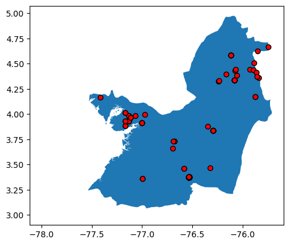

```python
fig, axes = plt.subplots()
area.plot(ax=axes)
# Realiza la operación de unión espacial (spatial join)
sps_valle = gpd.sjoin(sps, area, op='within')
sps_valle.plot(color="r", edgecolor="k", ax=axes)
```

## Ajustamos los raster

Este código realiza las siguientes tareas para un conjunto de archivos raster en formato GeoTIFF en una ubicación específica:

1. Itera a través de archivos GeoTIFF en una ubicación dada.
2. Para cada archivo:
- Abre el archivo original y obtiene sus metadatos.
- Lee los datos del raster.
- Reproyecta el raster para que coincida con la proyección EPSG:4326.
- Escribe los datos reproyectados en un nuevo archivo GeoTIFF con la proyección corregida.

```python
%%time
import rasterio.warp

for t in range(1):
    src_files_to_mosaic = []
    for fp in glob.glob(f'/content/drive/MyDrive/**/valle_del_cauca*.tif', recursive=True):
        # ...

        # Abrir el archivo raster original
        with rasterio.open(fp) as src_dataset:
            meta = src_dataset.meta
            meta.update(
                {
                    "nodata": -9999
                }
            )
            data = src_dataset.read()

            # Reproyectar el raster
            with rasterio.open(fp, 'w', **meta) as dst_dataset:
                dst_dataset.write(data)
                dst_dataset.close()

        # Reproyectar el archivo raster a EPSG:4326
        with rasterio.open(fp) as src_dataset:
            transform, width, height = rasterio.warp.calculate_default_transform(
                src_dataset.crs, "EPSG:4326", src_dataset.width, src_dataset.height, *src_dataset.bounds
            )
            kwargs = src_dataset.meta.copy()
            kwargs.update(
                {
                    "crs": "EPSG:4326",
                    "transform": transform,
                    "width": width,
                    "height": height
                }
            )

            with rasterio.open(fp, 'w', **kwargs) as dst_dataset:
                rasterio.warp.reproject(
                    source=rasterio.band(src_dataset, 1),
                    destination=rasterio.band(dst_dataset, 1),
                    src_transform=src_dataset.transform,
                    src_crs=src_dataset.crs,
                    dst_transform=transform,
                    dst_crs="EPSG:4326",
                    resampling=rasterio.enums.Resampling.nearest
                )
#creamos una nueva carpeta para almacenar los raster
os.mkdir("./tif")
```

```
CPU times: user 9.98 s, sys: 2.6 s, total: 12.6 s
Wall time: 31 s
```

Este código busca archivos en un directorio base que coincidan con el patrón "valle_del_cauca*.tif" y luego copia esos archivos a un directorio de destino. Luego, muestra un mensaje de éxito.

```python
import glob
import shutil

# Ruta del directorio base donde se realizará la búsqueda
base_dir = '/content/drive/MyDrive/'

# Patrón de búsqueda
search_pattern = base_dir + '**/valle_del_cauca*.tif'

# Directorio de destino
destination_dir = './tif/'

# Buscar archivos que coinciden con el patrón
matching_files = glob.glob(search_pattern, recursive=True)

# Copiar cada archivo a la carpeta de destino
for file in matching_files:
    shutil.copy(file, destination_dir)

print("Archivos copiados con éxito.")
```

```
Archivos copiados con éxito.
```

Este código crea mosaicos de imágenes raster al iterar a través de archivos en un directorio. Extrae metadatos y datos de cada archivo, incluyendo coordenadas, resolución y transformación espacial, y los almacena en diccionarios. Los mosaicos resultantes se almacenan en 'mosaicos', mientras que los metadatos se almacenan en 'meta_mosaicos'.

```python
mosaicos = {}
meta_mosaicos = {}

for fp in glob.glob(f'/content/tif/*.tif', recursive=True):
        # ...

        # Abrir el archivo raster original
  t = fp.split("/")[-1]
  with rasterio.open(fp) as src_dataset:
    meta = src_dataset.meta
    meta.update(
        {
            "nodata": -9999
        }
            )
    data = src_dataset.read()

  src = rasterio.open(fp)
  bounds = src.bounds
  transform = src.transform
  resolution = src.res

  # Extraer los valores necesarios
  x_min, y_min, x_max, y_max = bounds
  pixel_width = transform.a
  pixel_height = abs(transform.e)
  mosaic = src
  mosaicos[t] = mosaic
  out_trans = src.meta
  meta_mosaicos[t] = out_trans

# Observamos el nombre de cada archivo .tif que guardamos en el diccionario
mosaicos.keys()
```

```
dict_keys(['valle_del_cauca_precipitation_seasonality.tif', 'valle_del_cauca_mean_temperature_of_driest_quarter.tif', 'valle_del_cauca_mean_temperature_of_coldest_quarter.tif', 'valle_del_cauca_elevation.tif', 'valle_del_cauca_mean_temperature_of_warmest_quarter.tif', 'valle_del_cauca_temperature_se…
```

Este código crea una visualización de mapas de mosaicos de precipitación anual en el Valle del Cauca. Utiliza la biblioteca rasterio.plot para mostrar el mapa de precipitación en tonos de azul en un gráfico con ejes ajustados. Luego agrega contornos de área, ajusta una barra de colores y un título, y muestra el gráfico con una cuadrícula punteada.

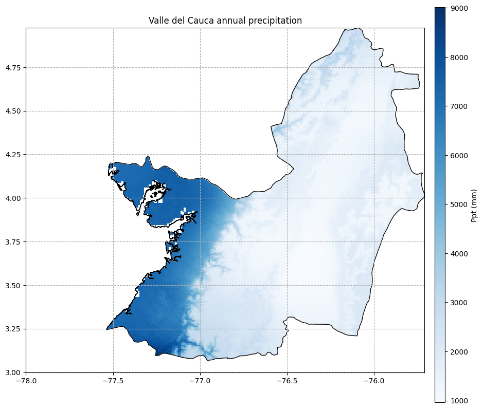

```python
fig, ax = plt.subplots(figsize=(10, 10))
image = rasterio.plot.show(mosaicos['valle_del_cauca_annual_precipitation.tif'], ax=ax, cmap="Blues")

area.plot(edgecolor="k", linewidth=1, facecolor='none', ax=ax)

# Ajustar tamaño de la barra de colores
cax = fig.add_axes([0.92, 0.101, 0.02, 0.769])
cbar = plt.colorbar(image.get_images()[0], cax=cax)
cbar.set_label('Ppt (mm)')
ax.set_title("Valle del Cauca annual precipitation")
ax.grid(linestyle="--")
plt.show()
```

## Capturemos algunos datos de los raster

Usando las coordenadas de las especies de estudios nos aseguramos que efectivamente las obervaciones esten dentro del area de interes y no este afuera generando valores nulos para nuestro dataset

Este código define una función que asigna 1.0 si una especie es 'Anacardium excelsum' y 0.0 si no lo es. Luego, aplica esta función a la columna 'acceptedScientificName' de un GeoDataFrame llamado 'sps_valle', creando una nueva columna 'Class'. También establece la referencia espacial del GeoDataFrame en EPSG:4326.

```python
# Función para asignar 1.0 si es 'Anacardium excelsum' y 0.0 para otras especies
def is_anacardium(especie):
    return 1.0 if especie == 'Anacardium excelsum (Bertero & Balb.) Skeels' else 0.0

# Crear la nueva columna usando la función 'apply'
sps_valle["Class"] = sps_valle['acceptedScientificName'].apply(is_anacardium)
sps_valle.crs = 'EPSG:4326'
sps_valle
```

|  | acceptedTaxonKey | acceptedScientificName | family | genus | decimalLongitude | decimalLatitude | elevation | continent | stateProvince | eventDate | ... | NAME_0 | ID_1 | NAME_1 | ID_2 | NAME_2 | TYPE_2 | ENGTYPE_2 | NL_NAME_2 | VARNAME_2 | Class |
| --- | --- | --- | --- | --- | --- | --- | --- | --- | --- | --- | --- | --- | --- | --- | --- | --- | --- | --- | --- | --- | --- |
| 0 | 3190513 | Carapa guianensis Aubl. | Meliaceae | Carapa | -76.994930 | 3.359870 | 186.0 | SOUTH_AMERICA | Valle del Cauca | 2017-01-01T00:00:00 | ... | Colombia | 30 | Valle del Cauca | 1032 | Jamundí | Municipio | Municipality | NaN | Cali | 0.0 |
| 0 | 3190513 | Carapa guianensis Aubl. | Meliaceae | Carapa | -76.994930 | 3.359870 | 186.0 | SOUTH_AMERICA | Valle del Cauca | 2017-01-01T00:00:00 | ... | Colombia | 30 | Valle del Cauca | 1032 | Jamundí | Municipio | Municipality | NaN | Cali | 0.0 |
| 0 | 3190513 | Carapa guianensis Aubl. | Meliaceae | Carapa | -76.974415 | 3.998835 | NaN | SOUTH_AMERICA | Valle del Cauca | 1961-04-25T00:00:00 | ... | Colombia | 30 | Valle del Cauca | 1032 | Jamundí | Municipio | Municipality | NaN | Cali | 0.0 |
| 0 | 3190513 | Carapa guianensis Aubl. | Meliaceae | Carapa | -77.166667 | 3.933333 | NaN | SOUTH_AMERICA | NaN | 1979-11-15T00:00:00 | ... | Colombia | 30 | Valle del Cauca | 1032 | Jamundí | Municipio | Municipality | NaN | Cali | 0.0 |
| 0 | 3190513 | Carapa guianensis Aubl. | Meliaceae | Carapa | -77.000000 | 3.916660 | 100.0 | SOUTH_AMERICA | Valle del Cauca | 1986-08-24T00:00:00 | ... | Colombia | 30 | Valle del Cauca | 1032 | Jamundí | Municipio | Municipality | NaN | Cali | 0.0 |
| ... | ... | ... | ... | ... | ... | ... | ... | ... | ... | ... | ... | ... | ... | ... | ... | ... | ... | ... | ... | ... | ... |
| 0 | 5544303 | Anacardium excelsum (Bertero & Balb.) Skeels | Anacardiaceae | Anacardium | -76.296620 | 3.836400 | 1005.0 | SOUTH_AMERICA | Valle del Cauca | 2021-12-07T00:00:00 | ... | Colombia | 30 | Valle del Cauca | 1032 | Jamundí | Municipio | Municipality | NaN | Cali | 1.0 |
| 0 | 5544303 | Anacardium excelsum (Bertero & Balb.) Skeels | Anacardiaceae | Anacardium | -76.296620 | 3.836400 | 1005.0 | SOUTH_AMERICA | Valle del Cauca | 2021-12-07T00:00:00 | ... | Colombia | 30 | Valle del Cauca | 1032 | Jamundí | Municipio | Municipality | NaN | Cali | 1.0 |
| 0 | 5544303 | Anacardium excelsum (Bertero & Balb.) Skeels | Anacardiaceae | Anacardium | -76.081806 | 4.335869 | 943.6 | SOUTH_AMERICA | Valle del Cauca | 2020-11-20T00:00:00 | ... | Colombia | 30 | Valle del Cauca | 1032 | Jamundí | Municipio | Municipality | NaN | Cali | 1.0 |
| 0 | 5544303 | Anacardium excelsum (Bertero & Balb.) Skeels | Anacardiaceae | Anacardium | -76.081806 | 4.335869 | 943.6 | SOUTH_AMERICA | Valle del Cauca | 2020-11-20T00:00:00 | ... | Colombia | 30 | Valle del Cauca | 1032 | Jamundí | Municipio | Municipality | NaN | Cali | 1.0 |
| 0 | 5544303 | Anacardium excelsum (Bertero & Balb.) Skeels | Anacardiaceae | Anacardium | -76.233333 | 4.333333 | 1000.0 | SOUTH_AMERICA | Valle del Cauca | 1986-04-06T00:00:00 | ... | Colombia | 30 | Valle del Cauca | 1032 | Jamundí | Municipio | Municipality | NaN | Cali | 1.0 |

90 rows × 28 columns

Este código extrae valores de píxeles de varios rasters (mapas de datos rasterizados) en ubicaciones de puntos. Los valores se asignan a columnas correspondientes en un GeoDataFrame. Los puntos con valores de precipitación y evapotranspiración positivos se muestran en el GeoDataFrame junto con estadísticas mínimas de esas columnas.

```python
# Copiar el GeoDataFrame original
colect_data = sps_valle[["acceptedScientificName",	"family",	"genus", "Class", "geometry"]].copy()

coord_list = [(x, y) for x, y in zip(colect_data["geometry"].x, colect_data["geometry"].y)]

# Iterar sobre los puntos del GeoDataFrame
# Iterar sobre los rasters en el diccionario mosaicos
for clave, raster in mosaicos.items():
  # Leer el valor del píxel correspondiente al punto
  valores_punto = [x[0] for x in raster.sample(coord_list)]

  # Asignar el valor del píxel a la columna correspondiente en el GeoDataFrame
  colect_data[clave.split(".")[0]] = valores_punto

colect_data = colect_data.loc[(colect_data["valle_del_cauca_annual_precipitation"] > 0) & (colect_data["valle_del_cauca_evapotranspiration"] > 0)]
display(colect_data)
print("--"*75)
colect_data.describe().loc["min",:]
```

|  | acceptedScientificName | family | genus | Class | geometry | valle_del_cauca_precipitation_seasonality | valle_del_cauca_mean_temperature_of_driest_quarter | valle_del_cauca_mean_temperature_of_coldest_quarter | valle_del_cauca_elevation | valle_del_cauca_mean_temperature_of_warmest_quarter | ... | valle_del_cauca_mean_temperature_of_wettest_quarter | valle_del_cauca_precipitation_of_driest_month | valle_del_cauca_isothermality | valle_del_cauca_precipitation_of_driest_quarter | valle_del_cauca_precipitation_of_warmest_quarter | valle_del_cauca_annual_precipitation | valle_del_cauca_annual_mean_temperature | valle_del_cauca_precipitation_of_wettest_quarter | valle_del_cauca_min_temperature_of_coldest_month | valle_del_cauca_mean_diurnal_range |
| --- | --- | --- | --- | --- | --- | --- | --- | --- | --- | --- | --- | --- | --- | --- | --- | --- | --- | --- | --- | --- | --- |
| 0 | Carapa guianensis Aubl. | Meliaceae | Carapa | 0.0 | POINT (-76.99493 3.35987) | 27.0 | 24.5 | 23.9 | 667 | 24.6 | ... | 24.1 | 194.0 | 89.0 | 592.0 | 689.0 | 3301.0 | 24.4 | 1101.0 | 19.0 | 9.8 |
| 0 | Carapa guianensis Aubl. | Meliaceae | Carapa | 0.0 | POINT (-76.99493 3.35987) | 27.0 | 24.5 | 23.9 | 667 | 24.6 | ... | 24.1 | 194.0 | 89.0 | 592.0 | 689.0 | 3301.0 | 24.4 | 1101.0 | 19.0 | 9.8 |
| 0 | Carapa guianensis Aubl. | Meliaceae | Carapa | 0.0 | POINT (-76.97441 3.99884) | 25.0 | 26.3 | 25.8 | 31 | 26.5 | ... | 25.8 | 322.0 | 90.0 | 1113.0 | 1248.0 | 7077.0 | 26.2 | 2281.0 | 22.1 | 7.5 |
| 0 | Carapa guianensis Aubl. | Meliaceae | Carapa | 0.0 | POINT (-77.16667 3.93333) | 32.0 | 26.1 | 25.5 | 38 | 26.3 | ... | 25.5 | 301.0 | 88.0 | 1028.0 | 1547.0 | 7494.0 | 25.9 | 2577.0 | 22.1 | 7.1 |
| 0 | Carapa guianensis Aubl. | Meliaceae | Carapa | 0.0 | POINT (-77.00000 3.91666) | 28.0 | 26.4 | 25.8 | 18 | 26.5 | ... | 25.8 | 298.0 | 90.0 | 1041.0 | 1174.0 | 7021.0 | 26.2 | 2357.0 | 22.1 | 7.5 |
| ... | ... | ... | ... | ... | ... | ... | ... | ... | ... | ... | ... | ... | ... | ... | ... | ... | ... | ... | ... | ... | ... |
| 0 | Anacardium excelsum (Bertero & Balb.) Skeels | Anacardiaceae | Anacardium | 1.0 | POINT (-76.29662 3.83640) | 32.0 | 23.5 | 23.0 | 996 | 23.7 | ... | 23.2 | 48.0 | 90.0 | 173.0 | 230.0 | 1086.0 | 23.5 | 358.0 | 17.6 | 11.0 |
| 0 | Anacardium excelsum (Bertero & Balb.) Skeels | Anacardiaceae | Anacardium | 1.0 | POINT (-76.29662 3.83640) | 32.0 | 23.5 | 23.0 | 996 | 23.7 | ... | 23.2 | 48.0 | 90.0 | 173.0 | 230.0 | 1086.0 | 23.5 | 358.0 | 17.6 | 11.0 |
| 0 | Anacardium excelsum (Bertero & Balb.) Skeels | Anacardiaceae | Anacardium | 1.0 | POINT (-76.08181 4.33587) | 35.0 | 23.8 | 23.3 | 929 | 24.1 | ... | 24.0 | 59.0 | 90.0 | 203.0 | 238.0 | 1310.0 | 23.8 | 447.0 | 17.7 | 11.7 |
| 0 | Anacardium excelsum (Bertero & Balb.) Skeels | Anacardiaceae | Anacardium | 1.0 | POINT (-76.08181 4.33587) | 35.0 | 23.8 | 23.3 | 929 | 24.1 | ... | 24.0 | 59.0 | 90.0 | 203.0 | 238.0 | 1310.0 | 23.8 | 447.0 | 17.7 | 11.7 |
| 0 | Anacardium excelsum (Bertero & Balb.) Skeels | Anacardiaceae | Anacardium | 1.0 | POINT (-76.23333 4.33333) | 39.0 | 19.8 | 19.3 | 1505 | 20.0 | ... | 19.3 | 66.0 | 92.0 | 247.0 | 386.0 | 1527.0 | 19.8 | 543.0 | 14.6 | 9.9 |

90 rows × 26 columns

```
Class                                                     0.000000
valle_del_cauca_precipitation_seasonality                25.000000
valle_del_cauca_mean_temperature_of_driest_quarter       17.300000
valle_del_cauca_mean_temperature_of_coldest_quarter      16.800000
valle_del_cauca_elevation                                12.000000
valle_del_cauca_mean_temperature_of_warmest_quarter      17.300000
valle_del_cauca_temperature_seasonality                   2.430000
valle_del_cauca_precipitation_of_coldest_quarter        300.000000
valle_del_cauca_precipitation_of_wettest_month          138.000000
valle_del_cauca_temperature_annual_range                  7.700000
valle_del_cauca_max_temperature_of_warmest_month         22.200000
valle_del_cauca_evapotranspiration                      105.666667
valle_del_cauca_mean_temperature_of_wettest_quarter      17.200000
valle_del_cauca_precipitation_of_driest_month            32.000000
valle_del_cauca_isothermality                            87.000000
valle_del_cauca_precipitation_of_driest_quarter         142.000000
valle_del_cauca_precipitation_of_warmest_quarter        222.000000
valle_del_cauca_annual_precipitation                   1041.000000
valle_del_cauca_annual_mean_temperature                  17.100000
valle_del_cauca_precipitation_of_wettest_quarter        350.000000
valle_del_cauca_min_temperature_of_coldest_month         12.400000
valle_del_cauca_mean_diurnal_range                        6.700000
Name: min, dtype: float64
```

# Implementando Modelos de Distribución de Especies

[figure not shown]

La metodologia de este modelo fue extraido de este repositorio:

> https://daniel-furman.github.io/Python-species-distribution-modeling/

Los modelos $RandomForest$, $ExtraTrees$, $XGBoost$ y $LGBM$ son clasificadores basados en árboles de decisión utilizados en **aprendizaje automático**. Cada uno combina múltiples árboles para mejorar la precisión y reducir el overfitting.

Son versátiles y pueden manejar datos complejos y no lineales, incluyendo características numéricas y categóricas. Estos modelos son resistentes al ruido y proporcionan importancias de características, permitiendo identificar características relevantes. Su uso es beneficioso en problemas de clasificación, proporcionando eficiencia, rendimiento y la capacidad de manejar grandes conjuntos de datos. Los algoritmos de ensamble optimizan la función de pérdida para mejorar el rendimiento del modelo en diversas aplicaciones como la de nuestro caso de estudio.

Si quieres indagar un poco mas te dejo aqui un post que habla un poco mas del tema de los [clasificadores basados en árboles de decisión](https://medium.com/riskified-technology/xgboost-lightgbm-or-catboost-which-boosting-algorithm-should-i-use-e7fda7bb36bc)

```python
# Colectamos las variables de interes en este caso "Class" y "geometry"
pa =  colect_data[['Class','geometry']]
pa
```

|  | Class | geometry |
| --- | --- | --- |
| 0 | 0.0 | POINT (-76.99493 3.35987) |
| 0 | 0.0 | POINT (-76.99493 3.35987) |
| 0 | 0.0 | POINT (-76.97441 3.99884) |
| 0 | 0.0 | POINT (-77.16667 3.93333) |
| 0 | 0.0 | POINT (-77.00000 3.91666) |
| ... | ... | ... |
| 0 | 1.0 | POINT (-76.29662 3.83640) |
| 0 | 1.0 | POINT (-76.29662 3.83640) |
| 0 | 1.0 | POINT (-76.08181 4.33587) |
| 0 | 1.0 | POINT (-76.08181 4.33587) |
| 0 | 1.0 | POINT (-76.23333 4.33333) |

90 rows × 2 columns

## Empezamos el entranamiento

```python
# Creación de carpetas para almacenar datos de esta sección del ejercicio
os.mkdir("inputs")  # Crear carpeta "inputs" para almacenar datos de entrada
os.mkdir("outputs")  # Crear carpeta "outputs" para almacenar resultados

# Copiar características climáticas recortadas al área de estudio
import shutil
for f in sorted(glob.glob(f'/content/tif/valle_del_cauca_*.tif', recursive=True)):
    print(f)  # Mostrar el nombre del archivo que se está copiando
    shutil.copy(f, './inputs')  # Copiar archivo a la carpeta "inputs"
```

```
/content/tif/valle_del_cauca_annual_mean_temperature.tif
/content/tif/valle_del_cauca_annual_precipitation.tif
/content/tif/valle_del_cauca_elevation.tif
/content/tif/valle_del_cauca_evapotranspiration.tif
/content/tif/valle_del_cauca_isothermality.tif
/content/tif/valle_del_cauca_max_temperature_of_warmest_month.tif
/content/tif/valle_del_cauca_mean_diurnal_range.tif
/content/tif/valle_del_cauca_mean_temperature_of_coldest_quarter.tif
/content/tif/valle_del_cauca_mean_temperature_of_driest_quarter.tif
/content/tif/valle_del_cauca_mean_temperature_of_warmest_quarter.tif
/content/tif/valle_del_cauca_mean_temperature_of_wettest_quarter.tif
/content/tif/valle_del_cauca_min_temperature_of_coldest_month.tif
/content/tif/valle_del_cauca_precipitation_of_coldest_quarter.tif
/content/tif/valle_del_cauca_precipitation_of_driest_month.tif
/content/tif/valle_del_cauca_precipitation_of_driest_quarter.tif
/content/tif/valle_del_cauca_precipitation_of_warmest_quarter.tif
/content/tif/valle_del_cauca_precipitation_of_wettest_month.tif
/content/tif/valle_del_cauca_precipitation_of_wettest_quarter.tif
/content/tif/valle_del_cauca_precipitation_seasonality.tif
/content/tif/valle_del_cauca_temperature_annual_range.tif
/content/tif/valle_del_cauca_temperature_seasonality.tif
```

Este código busca archivos TIFF en la carpeta "inputs" y los almacena en la lista "raster_features". Luego, muestra en la consola la cantidad de características raster encontradas en esa lista.

```python
# Obtener lista ordenada de archivos TIFF en la carpeta "inputs"
raster_features = sorted(glob.glob('./inputs/*.tif'))

# Verificar la cantidad de características (archivos) raster
print('\nHay', len(raster_features), 'características raster.')
```

```
Hay 21 características raster.
```

Este código carga datos de entrenamiento y objetivos desde archivos utilizando la biblioteca pyimpute. Los datos de entrenamiento se almacenan en train_xs y las etiquetas de respuesta en train_y. Los datos de objetivos se almacenan en target_xs y la información raster en raster_info. Luego, se verifica si las dimensiones coinciden con el tamaño de observaciones anteriores.

```python
# Importar funciones de carga de datos desde pyimpute
from pyimpute import load_training_vector
from pyimpute import load_targets

# Cargar datos de entrenamiento y objetivos desde archivos y obtener tamaños
train_xs, train_y = load_training_vector(pa, raster_features, response_field='Class') # Cargar datos de entrenamiento
target_xs, raster_info = load_targets(raster_features) # Cargar datos de objetivos
train_xs.shape, train_y.shape # Verificar tamaños, ¿coinciden con las observaciones anteriores?
```

```
((90, 21), (90,))
```

Este código importa clasificadores de aprendizaje automático, como Bosques Aleatorios, Árboles Extra, XGBoost y LightGBM. Luego, ajusta cada modelo a los datos de entrenamiento y realiza una validación cruzada para evaluar la precisión. Además, realiza predicciones espaciales utilizando los modelos ajustados en las características rasterizadas, generando imágenes de salida en carpetas correspondientes.

```python
# Importar clasificadores de aprendizaje automático
# Importar bibliotecas y definir clasificadores
%%time
from sklearn.ensemble import RandomForestClassifier
from sklearn.ensemble import ExtraTreesClassifier
from xgboost import XGBClassifier
from lightgbm import LGBMClassifier

CLASS_MAP = {
    'rf': (RandomForestClassifier()),  # Clasificador de Bosques Aleatorios
    'et': (ExtraTreesClassifier()),  # Clasificador de Árboles Extra
    'xgb': (XGBClassifier()),  # Clasificador XGBoost
    'lgbm': (LGBMClassifier())  # Clasificador LightGBM
    }

from pyimpute import impute
from sklearn import model_selection

# Ajuste de modelos y predicción espacial
for name, (model) in CLASS_MAP.items():
    # Validación cruzada para puntuaciones de precisión (mostradas como porcentaje)
    k = 5  # k-fold
    kf = model_selection.KFold(n_splits=k)
    accuracy_scores = model_selection.cross_val_score(model, train_xs, train_y, cv=kf, scoring='accuracy')
    print(name + " Precisión en Validación Cruzada %d-fold: %0.2f (+/- %0.2f)"
          % (k, accuracy_scores.mean() * 100, accuracy_scores.std() * 200))

    # Predicción espacial
    model.fit(train_xs, train_y)
    os.mkdir('outputs/' + name + '-images')  # Crear carpeta de salida para imágenes
    impute(target_xs, model, raster_info, outdir='outputs/' + name + '-images',
           class_prob=True, certainty=True)  # Realizar predicción espacial con características opcionales
```

```
rf Precisión en Validación Cruzada 5-fold: 97.78 (+/- 8.89)
et Precisión en Validación Cruzada 5-fold: 97.78 (+/- 8.89)
xgb Precisión en Validación Cruzada 5-fold: 97.78 (+/- 8.89)
lgbm Precisión en Validación Cruzada 5-fold: 97.78 (+/- 8.89)
CPU times: user 3min 4s, sys: 5.62 s, total: 3min 9s
Wall time: 2min 50s
```

Este código utiliza funciones de trazado de la biblioteca pylab para visualizar datos rasterizados de probabilidad. Define una función plotit para mostrar imágenes con mapas de colores y títulos. Luego, lee datos de probabilidad desde varios archivos raster y calcula el promedio de estas distribuciones. Finalmente, muestra un gráfico de la distribución promediada con un título específico y un mapa de colores "Greens".

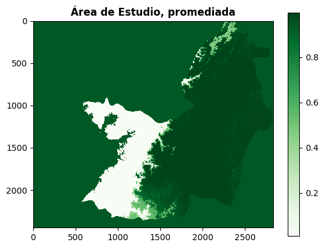

```python
from pylab import plt  # Importar funciones de trazado desde pylab

# Definir función trazadora espacial
def plotit(x, title, cmap="Blues"):
    plt.imshow(x, cmap=cmap, interpolation='nearest')  # Mostrar imagen con mapa de colores
    plt.colorbar()  # Agregar barra de colores
    plt.title(title, fontweight='bold')  # Establecer título en negrita

# Leer datos de probabilidad desde archivos raster
distr_rf = rasterio.open("outputs/rf-images/probability_1.0.tif").read(1)
distr_et = rasterio.open("outputs/et-images/probability_1.0.tif").read(1)
distr_xgb = rasterio.open("outputs/xgb-images/probability_1.0.tif").read(1)
distr_lgbm = rasterio.open("outputs/lgbm-images/probability_1.0.tif").read(1)

# Calcular promedio de las distribuciones
distr_averaged = (distr_rf + distr_et + distr_xgb + distr_lgbm) / 4

# Graficar distribución promedio con título y mapa de colores "Greens"
plotit(distr_averaged, "Área de Estudio, promediada", cmap="Greens")
```

```python
# A este se le conoce como valor nulo, es el dato de la primera fila y primera columna de nuestro raster
distr_averaged[0][0]
```

```
0.92917806
```

Este código importa funciones de trazado de Matplotlib y define una función para mostrar imágenes raster con opciones personalizadas. Luego, abre archivos raster utilizando rasterio, calcula el promedio de estos rasters y aplica una máscara para ocultar valores nodata. Finalmente, muestra un gráfico del raster promediado con un fondo gris claro y valores nodata ocultos, utilizando un mapa de colores 'OrRd'.

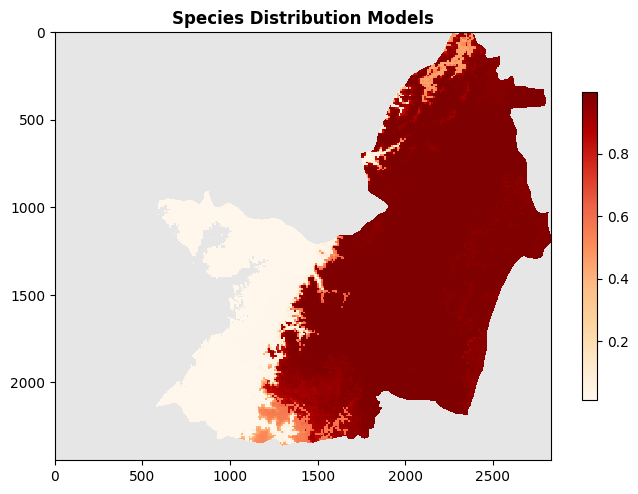

```python
import matplotlib.pyplot as plt

# Define los colores personalizados
def plotit(x, title, cmap="Blues"):
    fig, ax = plt.subplots(figsize=(8, 8))
    im = ax.imshow(x, cmap=cmap, interpolation='nearest')
    ax.set_title(title, fontweight='bold')
    ax.set_facecolor((0.9, 0.9, 0.9))  # Gray background
    cbar = fig.colorbar(im, ax=ax, shrink=0.5)
    plt.show()

# Abrir los archivos raster
with rasterio.open("outputs/rf-images/probability_1.0.tif") as rf_ds:
    distr_rf = rf_ds.read(1)

with rasterio.open("outputs/et-images/probability_1.0.tif") as et_ds:
    distr_et = et_ds.read(1)

with rasterio.open("outputs/xgb-images/probability_1.0.tif") as xgb_ds:
    distr_xgb = xgb_ds.read(1)

with rasterio.open("outputs/lgbm-images/probability_1.0.tif") as lgbm_ds:
    distr_lgbm = lgbm_ds.read(1)

# Calcular el promedio de los rasters
distr_averaged = (distr_rf + distr_et + distr_xgb + distr_lgbm) / 4

# Aplicar una máscara para ocultar los valores nodata
masked_distr_averaged = np.ma.masked_where(distr_averaged == distr_averaged[0][0], distr_averaged)

# Graficar el raster promediado sin mostrar los valores nodata
plotit(masked_distr_averaged, "Species Distribution Models", cmap='OrRd')
```

Este código define una función para trazar mapas espaciales con una paleta de colores personalizada. Se utilizan colores "yellow", "darkgreen", "lightgreen" y "red". Se crean segmentos en la barra de colores para representar diferentes rangos de valores. La función traza el mapa con la imagen y la barra de colores personalizada. Luego, se abre y calcula datos raster y se traza el mapa promediado con el título "Species Distribution Models" junto con un nombre científico.

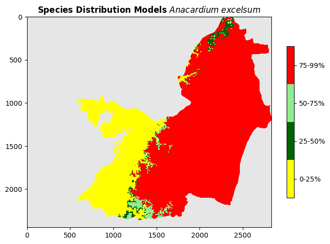

```python
from matplotlib.colors import ListedColormap  # Importar paleta de colores personalizada

# Define función para trazar mapas espaciales con colores personalizados
def plotit(x, title):
    cmap_colors = ["yellow", "darkgreen", "lightgreen","red"]  # Colores personalizados
    cmap = ListedColormap(cmap_colors)  # Crear paleta de colores

    bounds = [0, 0.25, 0.5, 0.75, 1]  # Límites para segmentos en la barra de colores

    fig, ax = plt.subplots(figsize=(8, 8))  # Crear figura y ejes
    im = ax.imshow(x, cmap=cmap, interpolation='nearest')  # Mostrar imagen con colores personalizados
    ax.set_title(title, fontweight='bold')  # Establecer título en negrita
    ax.set_facecolor((0.9, 0.9, 0.9))  # Fondo gris claro

    # Personalizar la barra de colores
    cbar = fig.colorbar(im, ax=ax, cmap=cmap, boundaries=bounds, ticks=[0.125, 0.375, 0.625, 0.875], shrink=0.5)
    cbar.set_ticks([0.125, 0.375, 0.625, 0.875])
    cbar.set_ticklabels(['0-25%', '25-50%', '50-75%', '75-99%'])
    plt.show()

# Abrir los archivos raster
with rasterio.open("outputs/rf-images/probability_1.0.tif") as rf_ds:
    distr_rf = rf_ds.read(1)

with rasterio.open("outputs/et-images/probability_1.0.tif") as et_ds:
    distr_et = et_ds.read(1)

with rasterio.open("outputs/xgb-images/probability_1.0.tif") as xgb_ds:
    distr_xgb = xgb_ds.read(1)

with rasterio.open("outputs/lgbm-images/probability_1.0.tif") as lgbm_ds:
    distr_lgbm = lgbm_ds.read(1)

# Calcular el promedio de los rasters
distr_averaged = (distr_rf + distr_et + distr_xgb + distr_lgbm) / 4

# Aplicar una máscara para ocultar los valores nodata
masked_distr_averaged = np.ma.masked_where(distr_averaged == distr_averaged[0][0], distr_averaged)

# Graficar el raster promediado sin mostrar los valores nodata
scientific_name = r"$\mathit{Anacardium\hspace{0.3}excelsum}$"
plotit(masked_distr_averaged, f"Species Distribution Models {scientific_name}")
```

## Exportamos el modelo

Este código crea un nuevo archivo raster georreferenciado en el formato GTiff. Define la ruta del archivo, dimensiones, sistema de referencia de coordenadas, transformación geoespacial, tipo de dato y valor nodata. Luego, utiliza la biblioteca rasterio para crear el archivo, escribir los datos promediados en él y lo guarda en la ubicación especificada por fp.

```python
# Definir ruta de archivo y parámetros para el nuevo archivo raster
fp = '/content/outputs/species_distribution_models.tif'
width = distr_averaged.shape[1]
height = distr_averaged.shape[0]
count = 1
crs = rasterio.crs.CRS.from_epsg(4326)
transform = meta_mosaicos['valle_del_cauca_elevation.tif']['transform']  # Transformación geoespacial
dtype = 'float32'
nodata = distr_averaged[0][0]  # Valor nodata

import numpy as np
import rasterio

# Crear un nuevo archivo raster georreferenciado
with rasterio.open(
    fp,
    "w",  # Modo de escritura
    driver="GTiff",  # Formato TIFF
    width=width,  # Ancho en píxeles
    height=height,  # Alto en píxeles
    count=count,  # Número de bandas
    crs=crs,  # Sistema de referencia de coordenadas
    transform=transform,  # Transformación geoespacial
    dtype=dtype,  # Tipo de dato
    nodata=nodata  # Valor nodata
) as dst:
    # Escribir los datos en el nuevo archivo raster
    dst.write(distr_averaged.reshape(1, height, width))
```

```
(2445, 2833)
```

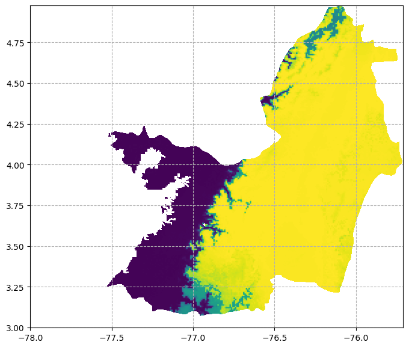

```python
# Ruta del archivo GeoTIFF
file_path = "/content/outputs/species_distribution_models.tif"

# Abrir el archivo con rasterio
with rasterio.open(file_path) as src:
    # Leer los datos del raster
    data = src.read(1)
    print(distr_et.shape)

    # Obtener el valor de "no data"
    nodata_value = src.nodata

    # Crear una máscara para eliminar el valor de "no data"
    mask = data != nodata_value
    data_masked = np.where(mask, data, np.nan)

    # Obtener la información de la transformación (marco de referencia)
    transform = src.transform

    # Configurar el color para el valor de "no data" como transparente (alpha=0)
    cmap = plt.cm.get_cmap("viridis")  # Puedes cambiar el mapa de colores aquí
    cmap.set_bad(alpha=0)

    # Crear el plot
    fig, axes = plt.subplots(figsize=(8, 8))

    # Graficar los datos con el marco de referencia y aplicar la configuración de color
    rasterio.plot.show(data_masked, transform=transform, cmap=cmap, vmin=0, vmax=1,ax=axes)

    # Mostrar el plot
    axes.grid(linestyle="--")
    plt.show()
```

# Conclusiones

> Este proyecto se centró en la implementación de Modelos de Distribución de Especies (SDMs) extraídos de un repositorio, demostrando la utilidad de Python en la creación rápida, accesible y efectiva de SDMs a partir de datos del GBIF.

> Al aprovechar variables satelitales de una amplia área, se ilustró cómo este proceso puede extenderse a nivel de cuencas hidrográficas o ecosistemas estratégicos.

> Si bien este estudio apenas rasca la superficie de las técnicas disponibles, su enfoque en el uso de las capacidades de aprendizaje automático en Python abre posibilidades para futuras investigaciones.

> Este ejercicio resulta ser una experiencia enriquecedora y puede servir como punto de partida para exploraciones más profundas en el campo de los SDMs.